# R Notebook

```r
# Load the data.
library("ggplot2")
aex = read.csv("data/AEX.csv")
aex$Date = as.Date(aex$Date)
```

# Part I

## 1

### 1.a

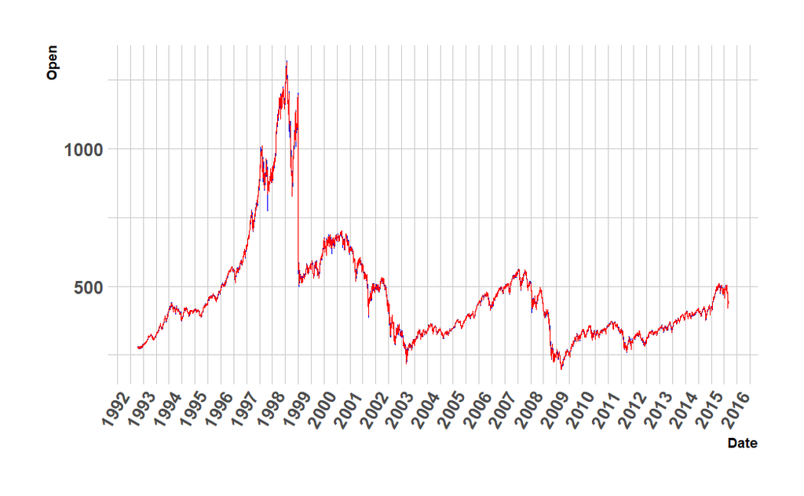

```r
library(hrbrthemes)


ggplot(aex) +
  geom_line(mapping=aes(x=Date, y=Open, group=1), color = "blue", linetype = "solid", linewidth = .1) +
  geom_line(mapping=aes(x=Date, y=Close, group=1), color = "red", linetype = "solid", linewidth = .1) +
  scale_x_date(date_breaks = "1 year", date_labels =  "%Y") +
  theme_ipsum() +
  theme(axis.text=element_text(face="bold"),axis.title.x=element_text(face="bold"),axis.title.y=element_text(face="bold"),axis.text.x=element_text(angle=60, hjust=1))
```

We notice a major decline happening around 1998 after a time of unprecedented growth. This crash likely was caused by the Russian financial crisis at the time, which resulted in steep inflation coupled with major loans issued by the IMF, on which they defaulted at that period in time.

Similarly we see the effect of the dot-com bubble in 2000, the effects of 9/11 in 2001/2002.

in 2008 we see the major sub-prime loan crisis, with bad loans being bundled and sold to third parties ad nauseam until defaults finally caught up and collapsed multiple banks.

### 1.b

No.

Prices one day depend on previous day. Furthermore, we can show by comparison of means for two different time sequences that these are highly unlikely to have been from the same underlying distribution.

```r
aex_1993_1995 = aex[aex$Date>="1993-01-01" & aex$Date<= "1995-01-01",]
aex_1996_1998 = aex[aex$Date>= "1996-01-01" & aex$Date<="1998-01-01",]

print(paste("1993-1995 Opening Prices mean:", mean(aex_1993_1995$Close), ", sample deviation: " , sd(aex_1993_1995$Close), ", observations: ", length(aex_1993_1995$Close), sep=""))
```

```
[1] "1993-1995 Opening Prices mean:373.979578366142, sample deviation: 44.6536484978979, observations: 508"
```

```r
print(paste("1996-1998 Opening Prices mean:", mean(aex_1996_1998$Close), ", sample deviation: " , sd(aex_1996_1998$Close), ", observations: ", length(aex_1993_1995$Close), sep=""))
```

```
[1] "1996-1998 Opening Prices mean:693.933683544554, sample deviation: 156.663006592056, observations: 508"
```

### 1.c

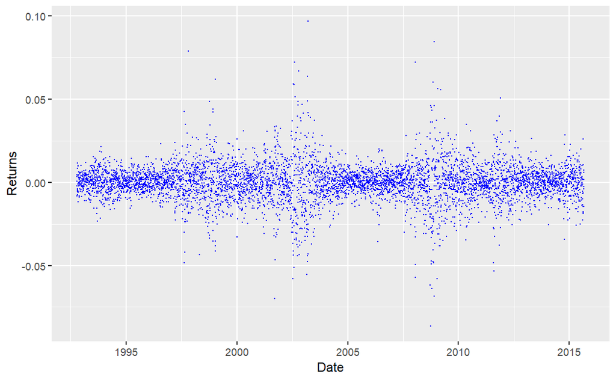

```r
library(ggplot2)
aex$Returns = (aex$Close - aex$Open) / aex$Open

ggplot(aex ) +
  geom_point(mapping=aes(x=Date, y=Returns, group=1), color = "blue", size = 0.05)
```

relevant summaries:

```r
aex$Year = format(aex$Date, "%Y")

data <- aex[(aex$Year >= 1993) & (aex$Year <= 1995),]$Returns
length(data)
```

```
[1] 761
```

```r
print(summary(data))
```

```
      Min.    1st Qu.     Median       Mean    3rd Qu.       Max.
-0.0233987 -0.0030488  0.0005772  0.0003837  0.0040220  0.0213818
```

```r
print(paste("SD: ", sd(data)))
```

```
[1] "SD:  0.00595008371791473"
```

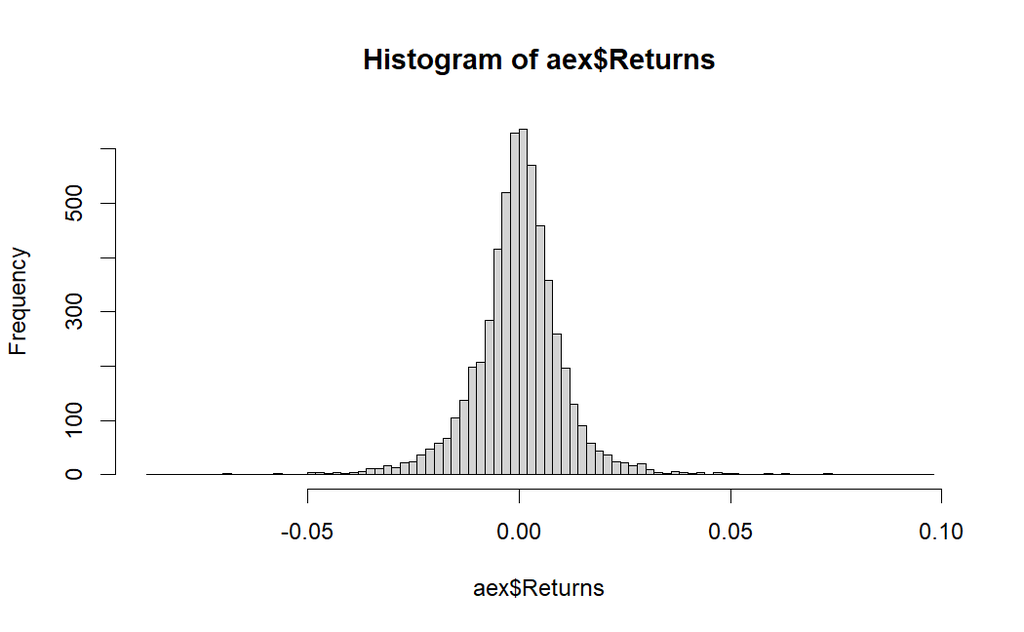

```r
hist(aex$Returns, breaks=100)
```

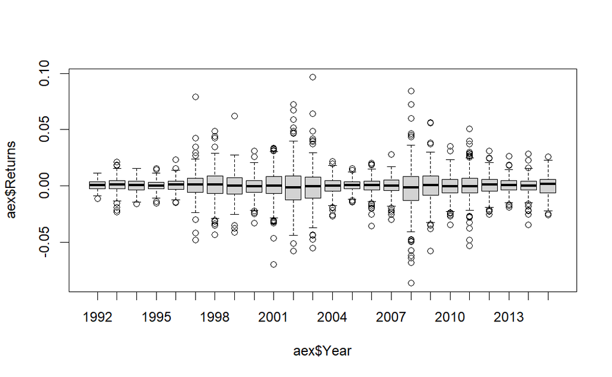

```r
boxplot(aex$Returns ~ aex$Year)
```

```r
aex$Year = format(aex$Date, "%Y")

data <- aex[(aex$Year >= 1996) & (aex$Year <= 1998),]$Returns
length(data)
```

```
[1] 758
```

```r
print(summary(data))
```

```
      Min.    1st Qu.     Median       Mean    3rd Qu.       Max.
-0.0483273 -0.0048306  0.0010206  0.0005942  0.0061310  0.0790771
```

```r
print(paste("SD: ", sd(data)))
```

```
[1] "SD:  0.0109258363888207"
```

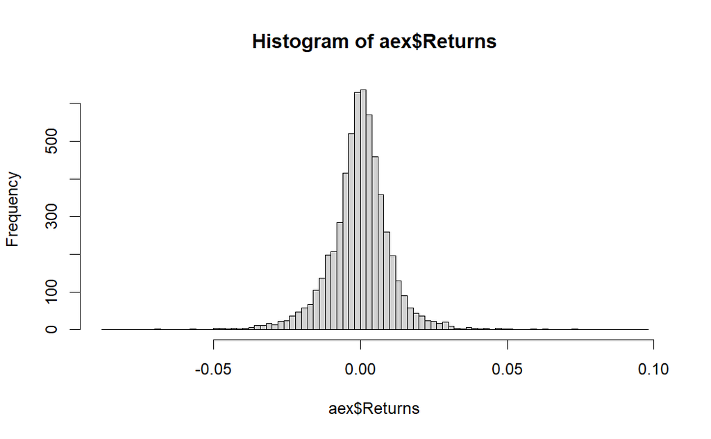

```r
hist(aex$Returns, breaks=100)
```

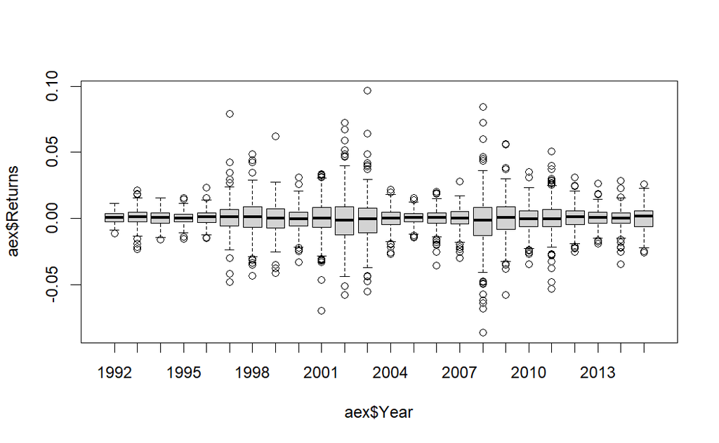

```r
boxplot(aex$Returns ~ aex$Year)
```

We observe a stable mean for the daily returns year by year, however, variance seems to still be influenced by time.

### 1.d

Due to the unstable variance over time, we cannot assume that these independent days are i.i.d samples from the same distribution. If they were from the same distribution, we would see (nearly) the same amount of variance and mean for all years, not a ~3x difference in some years compared to lower variance years.

## 2

### 2.a

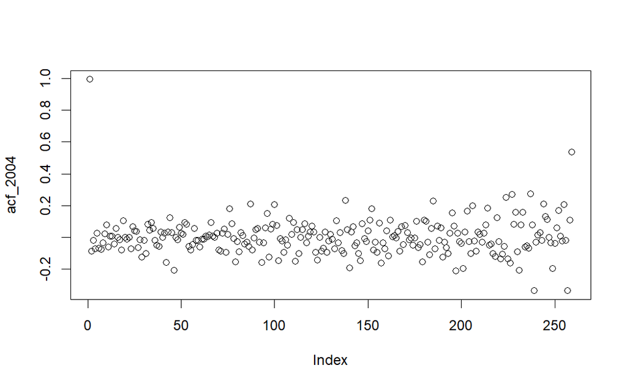

```r
aex_2004 = aex[aex$Year == 2004, ]
aex_2006 = aex[aex$Year == 2006, ]

auto_corr <- function(ordered, k) {
  sample_mean <- mean(ordered)
  sample_var <- var(ordered)
  count <- length(ordered)
  first_demeaned <- ordered[1:(count-k)] - sample_mean
  if (k > 0) {
    shifted_demeaned <- ordered[-(1:k)] - sample_mean
  } else {
    shifted_demeaned <- ordered - sample_mean
  }

  return((1/((count-k)*sample_var)) * sum(first_demeaned*shifted_demeaned))
}

acf_2004 = c()
for (k in 0:(length(aex_2004$Returns)-1)) {
  acf_2004 <- append(acf_2004, auto_corr(rev(aex_2004$Returns), k))
}

plot(acf_2004)
```

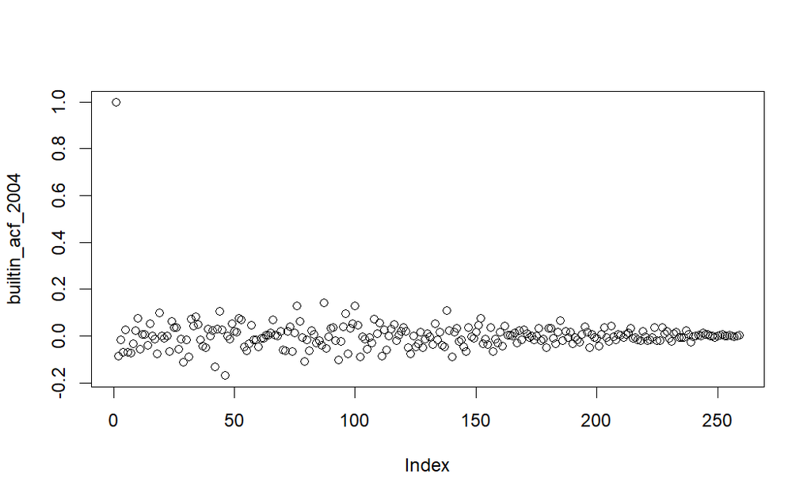

```r
builtin_acf_2004 = acf(rev(aex_2004$Returns), lag.max=(length(aex_2004$Returns)-1), plot=FALSE)$acf[]
plot(builtin_acf_2004)
```

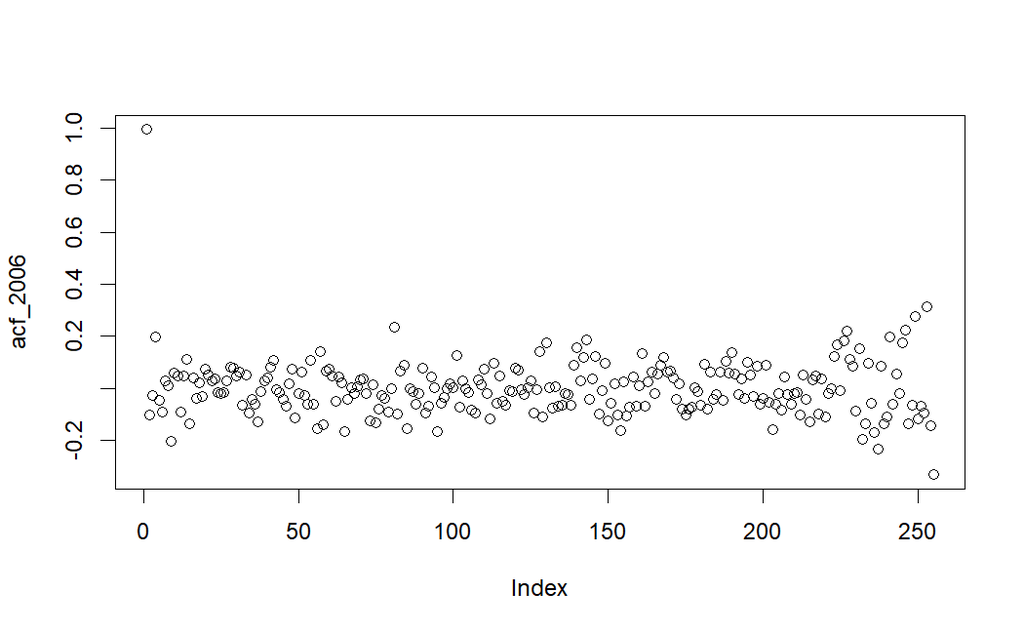

```r
acf_2006 = c()
for (k in 0:(length(aex_2006$Returns)-1)) {
  acf_2006 <- append(acf_2006, auto_corr(rev(aex_2006$Returns), k))
}

plot(acf_2006)
```

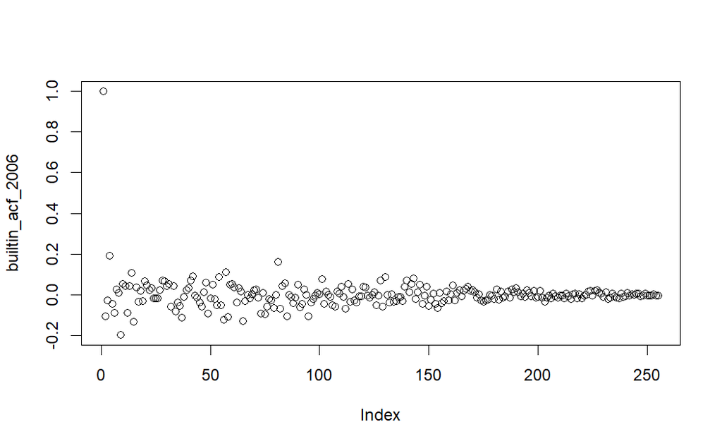

```r
builtin_acf_2006 = acf(rev(aex_2006$Returns), lag.max=(length(aex_2006$Returns)-1), plot=FALSE)$acf[]
plot(builtin_acf_2006)
```

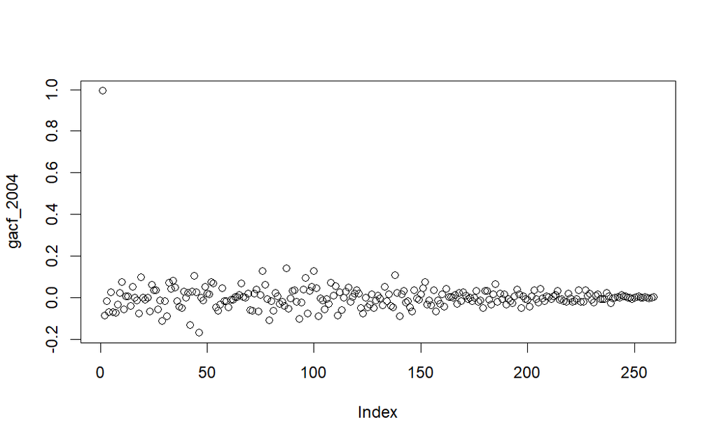

```r
guess <- function(ordered, k) {
  sample_mean <- mean(ordered)
  sample_var <- var(ordered)
  count <- length(ordered)
  first_demeaned <- ordered[1:(count-k)] - sample_mean
  if (k > 0) {
    shifted_demeaned <- ordered[-(1:k)] - sample_mean
  } else {
    shifted_demeaned <- ordered - sample_mean
  }

  return((1/((count)*sample_var)) * sum(first_demeaned*shifted_demeaned))
}

gacf_2004 = c()
for (k in 0:(length(aex_2004$Returns)-1)) {
  gacf_2004 <- append(gacf_2004, guess(rev(aex_2004$Returns), k))
}

gacf_2006 = c()
for (k in 0:(length(aex_2006$Returns)-1)) {
  gacf_2006 <- append(gacf_2006, guess(rev(aex_2006$Returns), k))
}

plot(gacf_2004)
```

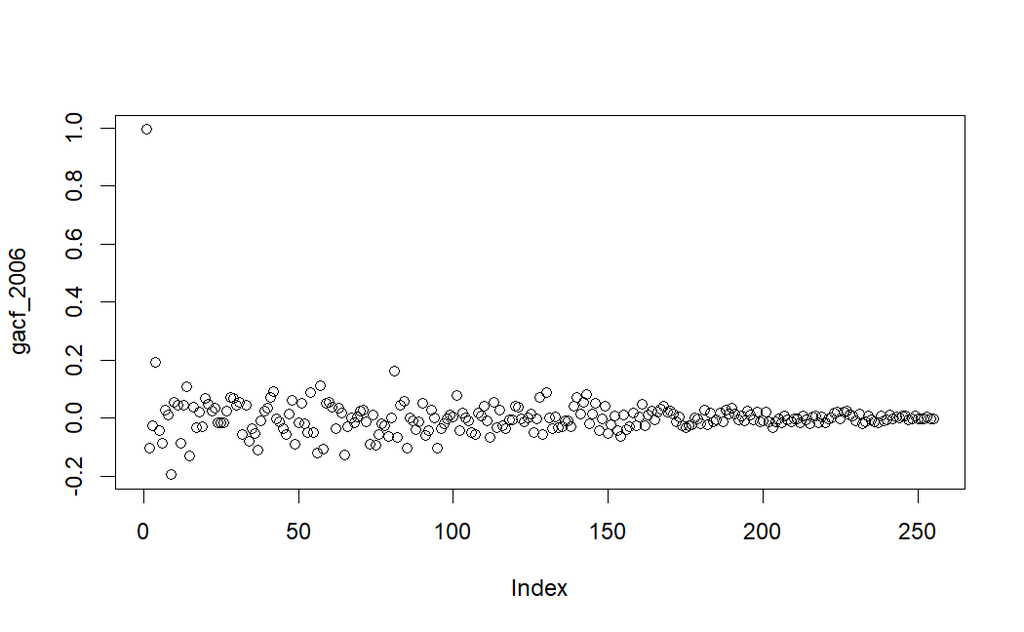

```r
plot(gacf_2006)
```

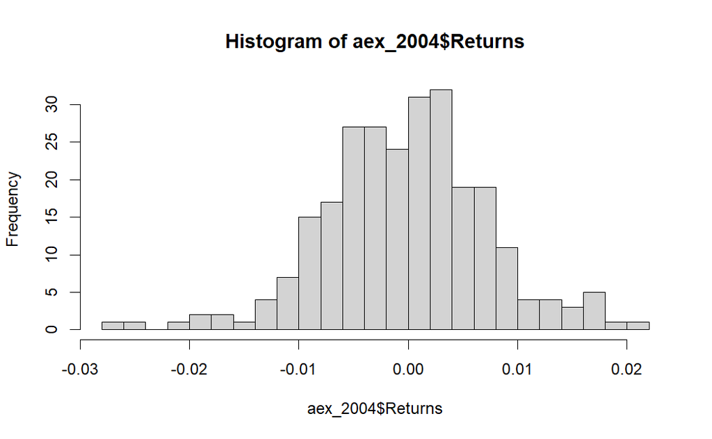

```r
library("car")

hist(aex_2004$Returns, breaks=20)
```

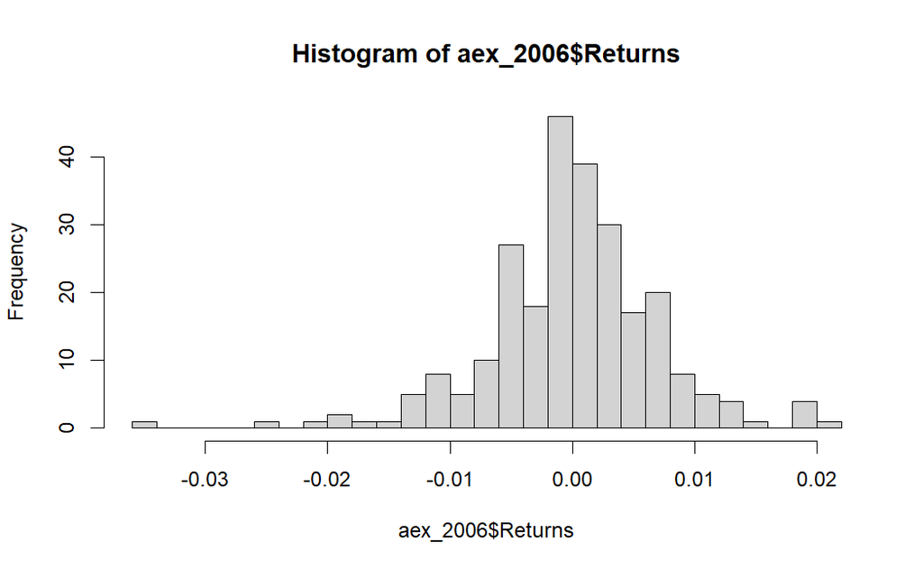

```r
hist(aex_2006$Returns, breaks=20)
```

```
[1] 208 205
```

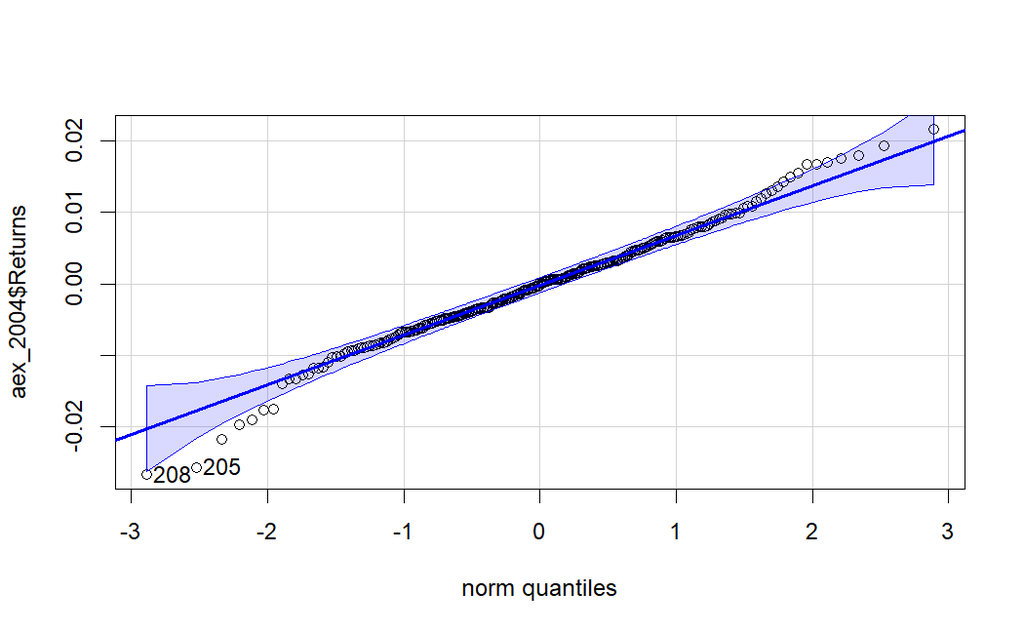

```r
qqPlot(aex_2004$Returns)
```

```
[1] 161 152
```

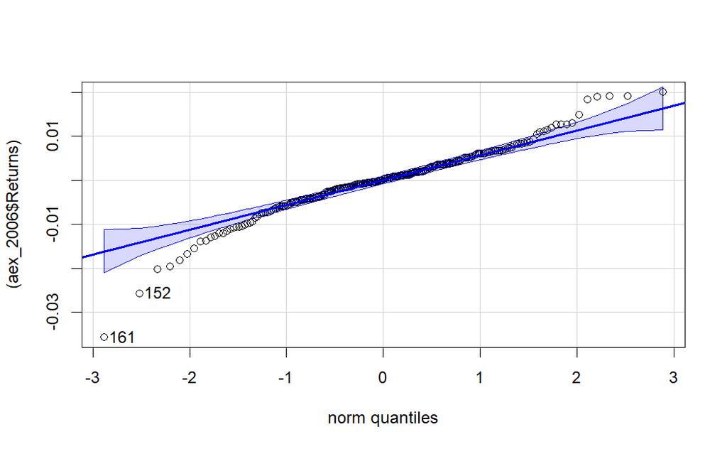

```r
qqPlot((aex_2006$Returns))
```

```
[1] 3193 1774
```

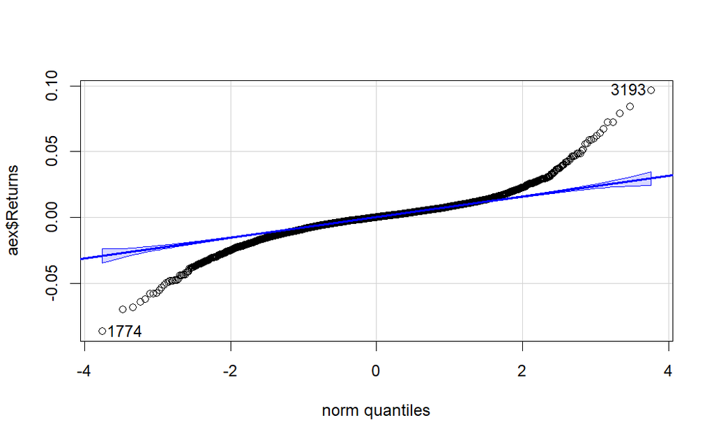

```r
qqPlot(aex$Returns)
```

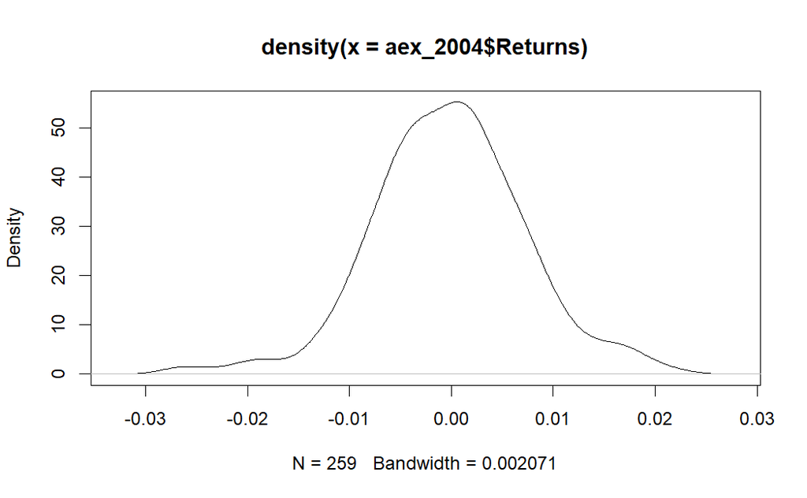

```r
plot(density(aex_2004$Returns))
```

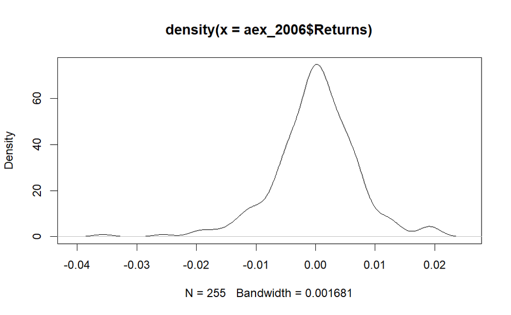

```r
plot(density(aex_2006$Returns))
```

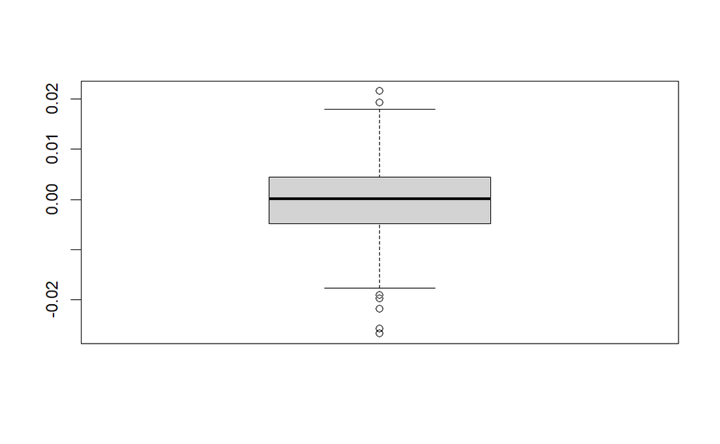

```r
boxplot(aex_2004$Returns)
```

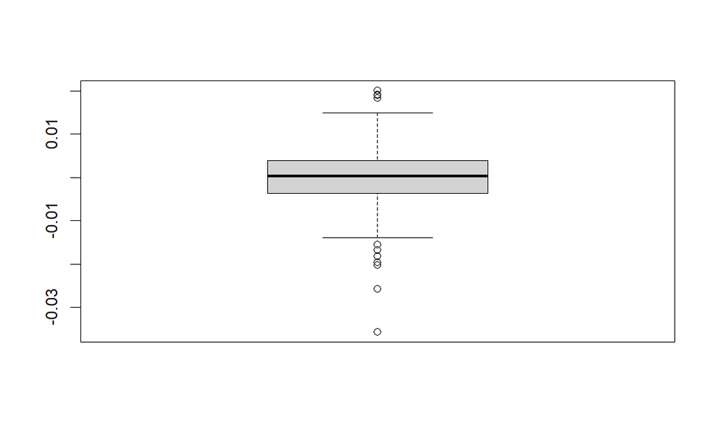

```r
boxplot(aex_2006$Returns)
```

2b: looks beautiful, not normal tho

look at snp500 preprocessing, in general for univariate data heavy-tail to normal transform exists, not sure if useful however2

```r
v_mm_est <- function(data) {
  second_moment_expected <- mean(data^2)
  v_mm <- -2*second_moment_expected/(1-second_moment_expected)
  return(v_mm)
}

est <- v_mm_est(aex_2004$Returns - mean(aex_2004$Returns))
est
```

```
[1] -0.0001134111
```

```r
library(LaplacesDemon)
library(dplyr)
library(MASS)
```

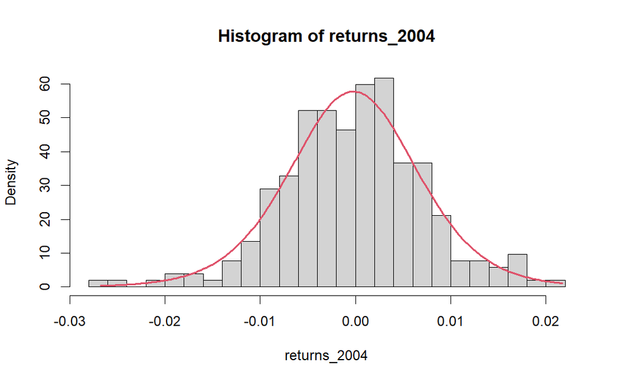

```r
returns_2004 <- aex_2004$Returns

params_2004 = fitdistr(returns_2004, "t")
df_2004 =params_2004$estimate[3]
mu_2004 = params_2004$estimate[1]
sd_2004 = params_2004$estimate[2]




x_2004 <- seq(min(returns_2004), max(returns_2004), length=length(returns_2004)-1)


fun_2004 <- dst(x_2004, mu=mu_2004, sigma=sd_2004, nu=df_2004)


hist(returns_2004, prob=TRUE, breaks=20)

lines(x_2004, fun_2004, col=2,lwd=2)
```

fitdistr uses maximum likelihood estimation. The optimization is done using the optim function in r. This is based on Nelder-Mead, quasi-Newton and conjugate-gradient algorithms

```r
returns_2006 <- aex_2006$Returns

params_2006 = fitdistr(returns_2006, "t")
df_2006 =params_2006$estimate[3]
mu_2006 = params_2006$estimate[1]
sd_2006 = params_2006$estimate[2]

library(dplyr)
library(report)
report::cite_packages()
```

[output not shown]

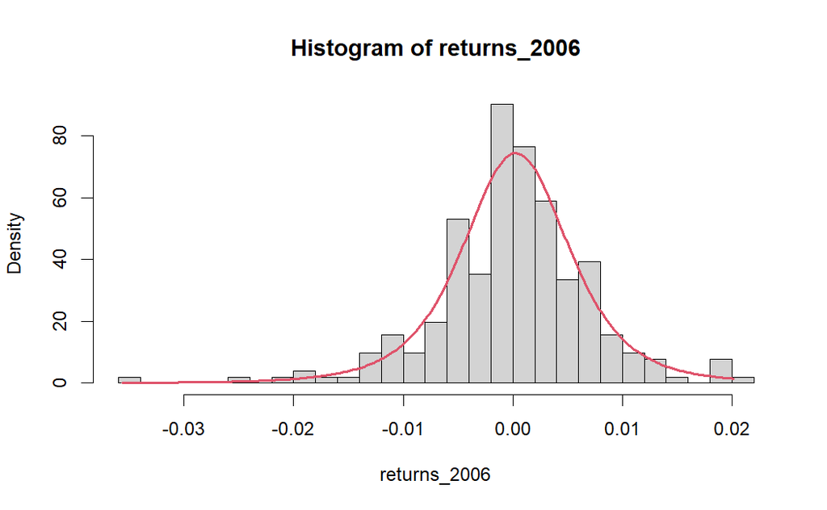

```r
x_2006 <- seq(min(returns_2006), max(returns_2006), length=length(returns_2006)-1)


fun_2006 <- dst(x_2006, mu=mu_2006, sigma=sd_2006, nu=df_2006)


hist(returns_2006, prob=TRUE, breaks=20)

lines(x_2006, fun_2006, col=2,lwd=2)
```

```r
VaR_2004 = qst(0.01, mu=params_2004$estimate[1], sigma=params_2004$estimate[2], nu=params_2004$estimate[3])
VaR_2006 = qst(0.01, mu=params_2006$estimate[1], sigma=params_2006$estimate[2], nu=params_2006$estimate[3])

VaR_2004
```

```
[1] -0.01895074
```

```r
VaR_2006
```

```
[1] -0.01901013
```

```r
quantile(aex_2004$Returns, probs=0.01)
```

```
         1%
-0.02063065
```

```r
quantile(aex_2006$Returns, probs=0.01)
```

```
         1%
-0.01974624
```

```r
mean_2004 = mean(aex_2004$Returns)
var_2004 = var(aex_2004$Returns)
sd_2004 = sd(aex_2004$Returns)
left_2004 = mean_2004 + qnorm(0.025)*sd_2004/sqrt(length(aex_2004))

right_2004 = mean_2004 + qnorm(1-0.025)*sd_2004/sqrt(length(aex_2004))
left_2004
```

```
[1] -0.00517935
```

```r
mean_2004
```

```
[1] -0.000250253
```

```r
right_2004
```

```
[1] 0.004678844
```

The mean is normally distributed.

```r
hist(aex_2004$Returns, prob=TRUE, breaks=20)

abline(v=left_2004,col='red', lwd=3, lty='dashed')
```

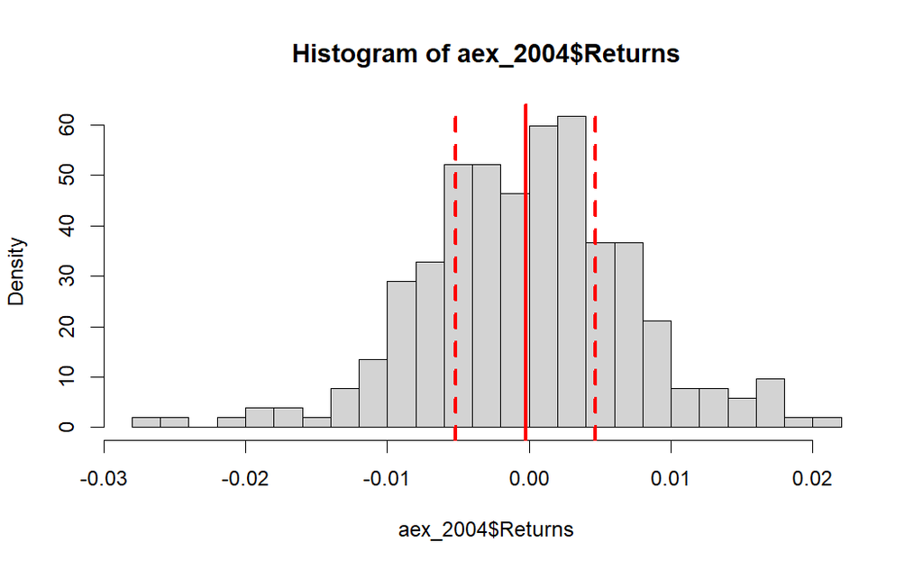

```r
abline(v=mean_2004,col='red', lwd=3)
abline(v=right_2004,col='red', lwd=3, lty='dashed')
```

```r
mean_2006 = mean(aex_2006$Returns)
var_2006 = var(aex_2006$Returns)
sd_2006 = sd(aex_2006$Returns)
left_2006 = mean_2006 + qnorm(0.025)*sd_2006/sqrt(length(aex_2006))

right_2006 = mean_2006 + qnorm(1-0.025)*sd_2006/sqrt(length(aex_2006))
left_2006
```

```
[1] -0.004628259
```

```r
mean_2006
```

```
[1] -1.627948e-06
```

```r
right_2006
```

```
[1] 0.004625003
```

```r
hist(aex_2006$Returns, prob=TRUE, breaks=20)

abline(v=left_2006,col='red', lwd=3, lty='dashed')
```

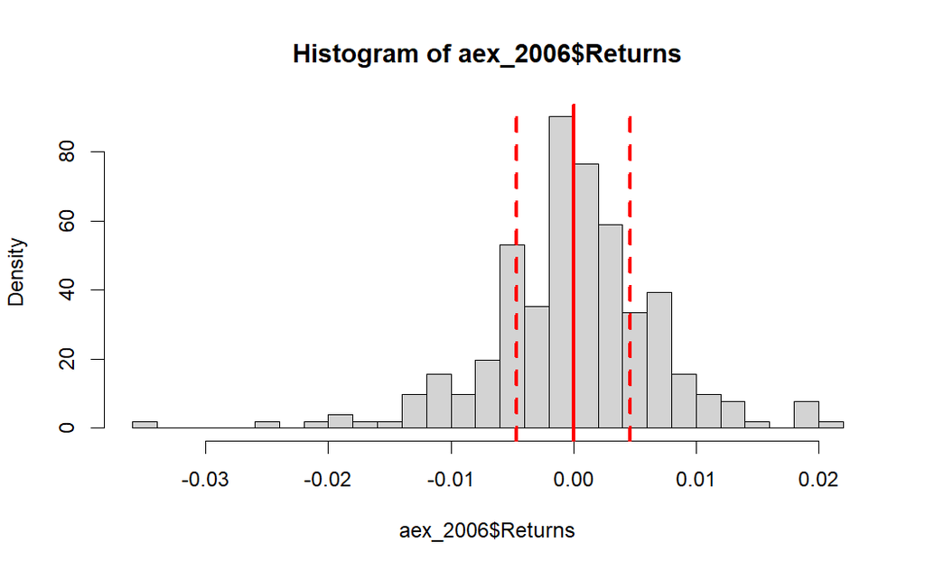

```r
abline(v=mean_2006,col='red', lwd=3)
abline(v=right_2006,col='red', lwd=3, lty='dashed')
```